# Cyclistics Case Study

Sam Casillas

2022-11-05

## Business Task

Cyclistic’s Marketing Analyst Team has been tasked with analyzing the company’s customer base, casual riders and paid members, to provide possible recommendations to increase memberships. The presentation needs to convince the Marketing Director and Executive Board to take action.

## Ask

- What is/are the problem(s) you are trying to solve?
  - Answered above.
- How can your insights drive business decisions?
  - This analysis should give all stakeholders the necessary information to make a decision on whether to implement presented recommendations.

## Prepare

- Where is your data located and how is it organized?
  - The data is located on the company’s fictitious shared files and the organization is shown below.
- Is your data reliable, objective, complete, current, and cited?
  - For this excercise, since Cyclistics is a made-up company the data provided is assumed (for this exercise only) to be reliable, objective, complete, current and cited. However, real-life scenarios require Analysts to consider this and if data doesn’t meet ROCCC then he/she may not be able to provide reasonable analysis to their stakeholders.
- How did you verify the data’s integrity?
  - The assumptions for this exercise is that the data has been extracted from the company’s database and that the data is free from bias and credibility issues.

###Environment Setup

Notes: The following packages will be installed

- Tidyverse
- Lubridate
- ggplot2
- readr
- data.table
- rmarkdown
- hms
- dplyr

```r
library(tidyverse)
library(data.table)
library(readr)
library(lubridate)
```

```r
library(ggplot2)
library(rmarkdown)
library(dplyr)
library(hms)
getwd()
```

```
## [1] "C:/Users/casil/Desktop/CaseStudy_Cyclistic/.csv"
```

```r
fileslist <- setwd("C:\\Users\\casil\\Desktop\\CaseStudy_Cyclistic\\.csv")
```

```r
cycl_data <- list.files(path = fileslist,
                        pattern = "*.csv", full.names = TRUE) %>%
  lapply(read_csv) %>%
  bind_rows
```

###View data variables

```r
glimpse(cycl_data)
```

```
## Rows: 5,828,235
## Columns: 14
## $ ride_id            <chr> "620BC6107255BF4C", "4471C70731AB2E45", "26CA69D43D…
## $ rideable_type      <chr> "electric_bike", "electric_bike", "electric_bike", …
## $ started_at         <chr> "10/22/2021 12:46", "10/21/2021 9:12", "10/16/2021 …
## $ ended_at           <chr> "10/22/2021 12:49", "10/21/2021 9:14", "10/16/2021 …
## $ start_station_name <chr> "Kingsbury St & Kinzie St", NA, NA, NA, NA, NA, NA,…
## $ start_station_id   <chr> "KA1503000043", NA, NA, NA, NA, NA, NA, NA, NA, NA,…
## $ end_station_name   <chr> NA, NA, NA, NA, NA, NA, NA, NA, NA, NA, NA, NA, NA,…
## $ end_station_id     <chr> NA, NA, NA, NA, NA, NA, NA, NA, NA, NA, NA, NA, NA,…
## $ start_lat          <dbl> 41.88919, 41.93000, 41.92000, 41.92000, 41.89000, 4…
## $ start_lng          <dbl> -87.63850, -87.70000, -87.70000, -87.69000, -87.710…
## $ end_lat            <dbl> 41.89000, 41.93000, 41.94000, 41.92000, 41.89000, 4…
## $ end_lng            <dbl> -87.63000, -87.71000, -87.72000, -87.69000, -87.690…
## $ member_casual      <chr> "member", "member", "member", "member", "member", "…
## $ ride_length        <time> 00:03:08, 00:01:37, 00:07:47, 00:01:15, 00:08:16, …
```

## Process

```r
cycl_data$started_at <- strptime(cycl_data$started_at, "%m/%d/%Y %H:%M")
cycl_data$ended_at <- strptime(cycl_data$ended_at, "%m/%d/%Y %H:%M")


cycl_data$year <- format(as.Date(cycl_data$started_at), "%Y")
cycl_data$month <- format(as.Date(cycl_data$started_at), "%m")

cycl_data$weekday_name <- format(as.Date(cycl_data$started_at), "%A")

cycl_data$day_of_week <- factor(cycl_data$weekday_name,
                                levels = c("Sunday", "Monday", "Tuesday", "Wednesday", "Thursday", "Friday", "Saturday"))
```

```r
cycl_data$day_of_week <- as.integer(cycl_data$day_of_week)
cycl_data$month <- as.integer(cycl_data$month)
cycl_data$year <- as.integer(cycl_data$year)
```

```r
clean_cycl_data <- cycl_data[!duplicated(cycl_data$ride_id), ]
```

## Analyze

- Has your data been properly formatted?
  - Yes, I have properly formatted each variable.
- What trends/relationships did you discover?

  *Casual riders are using the bike program more on weekends and the Members are using the bikes consistently throughout the week;largest usage is during the work week.

```r
ridertype_days <- clean_cycl_data %>%
  group_by(member_casual, day_of_week) %>%
  count(day_of_week)
```

```r
grp_riders_len <- clean_cycl_data %>%
  group_by(member_casual) %>%
  summarise(rider_ct = n(),
            median_ride_len = median(ride_length))

grp_riders_len
```

```
## # A tibble: 2 × 3
##   member_casual rider_ct median_ride_len
##   <chr>            <int> <time>
## 1 casual         2401279    NA
## 2 member         3426939    NA
```

## Share

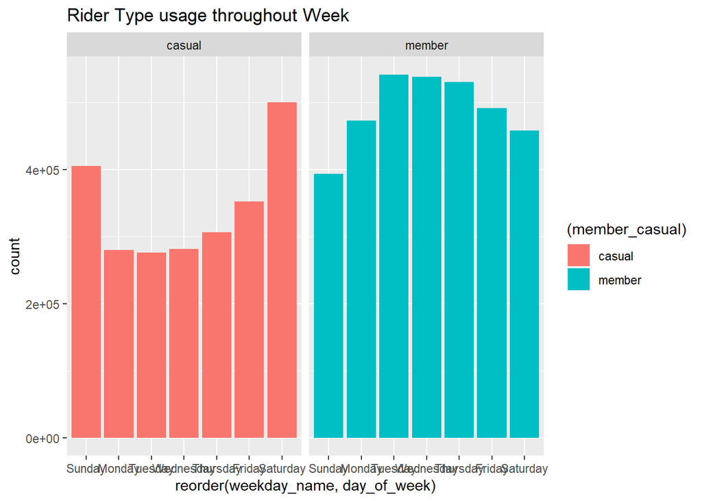

```r
ggplot(clean_cycl_data)+
  geom_bar(aes(x = reorder(weekday_name,day_of_week), fill=(member_casual)))+
  facet_wrap(~member_casual)+
  labs(title = "Rider Type usage throughout Week")
```

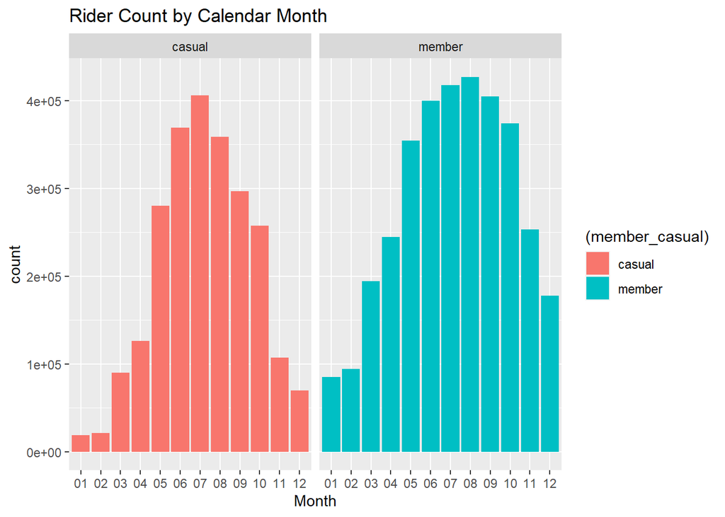

```r
ggplot(clean_cycl_data,
       aes(x = as.factor(format(started_at, format = "%m"))))+
  geom_bar(aes(fill = (member_casual)))+
  scale_x_discrete(name = 'Month')+
  facet_wrap(~member_casual)+
  labs(title = "Rider Count by Calendar Month")
```

## Act

- What is your final conclusion based on your analysis?
  - I would recommend to the Marketing Director and Executive Director that our casual riders are using our products more between the months of May - Oct. Also, I recommend that they should develop short term memberships that will attract casual riders while they are exploring what the city experience.
  - Unfortunately, the data doesn’t definitively communicate if the same casual riders are reusing our services over long periods of time. The large influx of casual users can be due to higher tourism during the months of May - Oct.
- What next steps would your stakeholders take based on your findings?
  - The Marketing Director would present any potential plans that will attract more frequent riders and convincing them to purchase memberships.
  - Executive Director would decide if the presented plans will be suitable for his desire to increase memberships and consistent customers.